# Forecasting de la Demanda Energetica en California

#### **Caso**:

Nuestro caso principal es estudiar la demanda energética de California, cabe destacar que es el tercer estado con mayor Extensión de los Estados Unidos de América, el equivalente al 85% del territorio Español, además de ser el primer mercado de los Estados Unidos, con un PIB de 2.656.080 millones de dólares, lo que supone el 14,2% del PIB de un país, Estados Unidos, cuyo PIB representa el 24% del total mundial.

También sabemos que California es hogar de varias regiones económicas importantes como Hollywood, Valle Central de California, Tech Coast y Sillicon Valley

- Disponemos de una base de datos sobre la demanda de energergetica de California desde 1/07/2015 al 30/11/2021

- Region: En este caso california
- UTC time: Tiempo universal coordinado
- Local date: La fecha de la zona
- Local hour: La hora de la zona
- Local time: Concatenación de 'Local date' y 'Local hour'
- Time zone: La zona horaria, en este caso pacífico
- D: La demanda energética

#### **Objetivos**:

En el presente análisis desarrollaremos distintos algoritmos para predecir:

- Los 7 primeros días de diciembre de 2021 en perioricidad horaria (01/12/2021-07/12/2021)
- Los 15 primeros días de diciembre de 2021 en perioricidad diaría (01/12/2021-15/12/2021)

En esta caso nos centraremos en la periocidad `horaria`

#### Cargamos librerias

```python
# Tratamiento de datos
# ==============================================================================
import numpy as np
import pandas as pd

# Gráficos
# ==============================================================================
import matplotlib.pyplot as plt
import seaborn as sns
from statsmodels.graphics.tsaplots import plot_acf
from statsmodels.graphics.tsaplots import plot_pacf
plt.style.use('fivethirtyeight')

# Modelado y Forecasting
# ==============================================================================
from sktime.performance_metrics.forecasting import mean_absolute_percentage_error
from sktime.performance_metrics.forecasting import MeanSquaredError
from sktime.utils.plotting import plot_series
rmse = MeanSquaredError(square_root=True)
from sklearn.metrics import mean_absolute_error
from sktime.utils.plotting import plot_series
from sktime.forecasting.arima import AutoARIMA
# Autocorrelation Fuction Package
from sktime.utils.plotting import plot_correlations
from sktime.transformations.series.boxcox import LogTransformer
from sktime.forecasting.ets import AutoETS



# Configuración warnings
# ==============================================================================
import warnings
warnings.filterwarnings('ignore')
```

#### Datos:

- Region: En este caso california
- UTC time: Tiempo universal coordinado
- Local date: La fecha de la zona
- Local hour: La hora de la zona
- Local time: Concatenación de 'Local date' y 'Local hour'
- Time zone: La zona horaria, en este caso pacífico
- D: La demanda energética

#### Leemos los datos

```python
df_energy = pd.read_excel('DemandaEnergia.xlsx')
df_energy.set_index('Local time')
```

| Local time | Region | UTC time | Local date | Local hour | Time zone | D |
| --- | --- | --- | --- | --- | --- | --- |
| 2015-07-01 01:00:00 | CAL | 2015-07-01 08:00:00 | 2015-07-01 | 1 | Pacific | 38210 |
| 2015-07-01 02:00:00 | CAL | 2015-07-01 09:00:00 | 2015-07-01 | 2 | Pacific | 35171 |
| 2015-07-01 03:00:00 | CAL | 2015-07-01 10:00:00 | 2015-07-01 | 3 | Pacific | 33243 |
| 2015-07-01 04:00:00 | CAL | 2015-07-01 11:00:00 | 2015-07-01 | 4 | Pacific | 31955 |
| 2015-07-01 05:00:00 | CAL | 2015-07-01 12:00:00 | 2015-07-01 | 5 | Pacific | 31199 |
| ... | ... | ... | ... | ... | ... | ... |
| 2021-11-30 11:00:00 | CAL | 2021-11-30 19:00:00 | 2021-11-30 | 11 | Pacific | 29068 |
| 2021-11-30 12:00:00 | CAL | 2021-11-30 20:00:00 | 2021-11-30 | 12 | Pacific | 28769 |
| 2021-11-30 13:00:00 | CAL | 2021-11-30 21:00:00 | 2021-11-30 | 13 | Pacific | 29180 |
| 2021-11-30 14:00:00 | CAL | 2021-11-30 22:00:00 | 2021-11-30 | 14 | Pacific | 29719 |
| 2021-11-30 15:00:00 | CAL | 2021-11-30 23:00:00 | 2021-11-30 | 15 | Pacific | 30512 |

56272 rows × 6 columns

Realizamos el tratamiento de datos adecuado para nuestra prediccion

```python
#Eliminamos valores duplicados en la columna "Local Hour"
df_without_duplicates = df_energy.drop_duplicates(subset=['Local time'])
```

```python
#Estudiando las columnas podemos ver que "Región" y "Time zone" no nos aporta ningun tipo de información para nuestra prediccion
df_energy = df_without_duplicates.drop(['Region','Time zone','UTC time'], axis=1)
```

Renombramos las variables

```python
df_energy.rename(columns={'D': 'Demand', 'Local date': 'Local_date', 'Local hour': 'Local_hour', 'Local time': 'Local_time'}, inplace=True)
```

Eliminamos las horas correspondiente a 25

```python
df_energy.drop(df_energy.loc[df_energy['Local_hour']==25].index, inplace=True)
```

Estudiamos duplicados y nulos

```python
print("Datos duplicados: ", df_energy.duplicated().sum())
print("Datos nulos por columna: \n", df_energy.isnull().sum())
```

```
Datos duplicados:  0
Datos nulos por columna:
 Local_date    0
Local_hour    0
Local_time    0
Demand        0
dtype: int64
```

```python
df_hour = df_energy.copy()
```

Eliminamos las columnas que no consideramos relevantes

```python
df_hour = df_hour.drop(['Local_date','Local_hour'], axis=1)
```

Ponemos la columna 'Local time' como indice y referimos la frecuencia

```python
df_hour = df_hour.set_index('Local_time')
df_hour.index = pd.PeriodIndex(df_hour.index, freq = 'H')
```

Zoom

- Al utilizar la herramienta de zoom podemos apreciar la clara estacionalidad semanal, consumos más elevados los días laborables respecto a los fines de semana, además se ven influenciados los consumos por el consumo del dia anterior

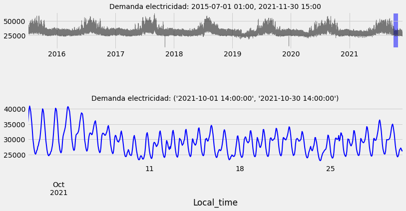

```python
zoom = ('2021-10-01 14:00:00','2021-10-30 14:00:00')

fig = plt.figure(figsize=(12, 6))
grid = plt.GridSpec(nrows=8, ncols=1, hspace=0.6, wspace=0)

main_ax = fig.add_subplot(grid[1:3, :])
zoom_ax = fig.add_subplot(grid[5:, :])

df_hour.Demand.plot(ax=main_ax, c='black', alpha=0.5, linewidth=0.5)
min_y = min(df_hour.Demand)
max_y = max(df_hour.Demand)
main_ax.fill_between(zoom, min_y, max_y, facecolor='blue', alpha=0.5, zorder=0)
main_ax.set_xlabel('')

df_hour.loc[zoom[0]: zoom[1]].Demand.plot(ax=zoom_ax, color='blue', linewidth=2)

main_ax.set_title(f'Demanda electricidad: {df_hour.index.min()}, {df_hour.index.max()}', fontsize=14)
zoom_ax.set_title(f'Demanda electricidad: {zoom}', fontsize=14)
plt.subplots_adjust(hspace=1)
```

#### Distribucion demanda por mes

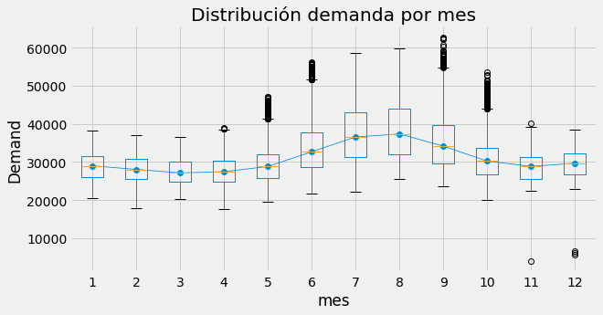

```python
boxplot_month = df_hour.copy()

fig, ax = plt.subplots(figsize=(10, 5))
boxplot_month['mes'] = boxplot_month.index.month
boxplot_month.boxplot(column='Demand', by='mes', ax=ax,)
boxplot_month.groupby('mes')['Demand'].median().plot(style='o-', linewidth=0.8, ax=ax)
ax.set_ylabel('Demand')
ax.set_title('Distribución demanda por mes')
fig.suptitle('');
```

#### Distribucion demanda por dia de la semana

- Apreciamos una menor demanda energetica cuando es fin de semana

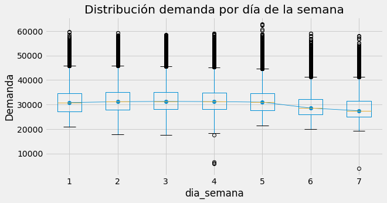

```python
boxplot_week = df_hour.copy()

fig, ax = plt.subplots(figsize=(10, 5))
boxplot_week['dia_semana'] = boxplot_week.index.day_of_week + 1
boxplot_week.boxplot(column='Demand', by='dia_semana', ax=ax)
boxplot_week.groupby('dia_semana')['Demand'].median().plot(style='o-', linewidth=0.8, ax=ax)
ax.set_ylabel('Demanda')
ax.set_title('Distribución demanda por día de la semana')
fig.suptitle('');
```

#### Distribucion demanda por hora del dia

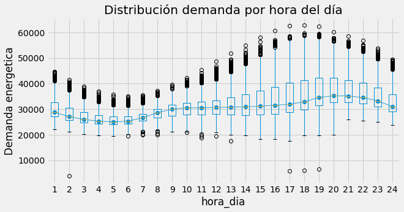

```python
boxplot_day = df_hour.copy()

fig, ax = plt.subplots(figsize=(10, 5))
boxplot_day['hora_dia'] = boxplot_day.index.hour + 1
boxplot_day.boxplot(column='Demand', by='hora_dia', ax=ax)
boxplot_day.groupby('hora_dia')['Demand'].median().plot(style='o-', linewidth=0.8, ax=ax)
ax.set_ylabel('Demanda energetica')
ax.set_title('Distribución demanda por hora del día')
fig.suptitle('');
```

Aplicamos logaritmos a nuestra serie

```python
transformer = LogTransformer()
log_hour= transformer.fit_transform(df_hour)
log_hour.tail()
```

|  | Demand |
| --- | --- |
| 2021-11-30 11:00 | 10.277393 |
| 2021-11-30 12:00 | 10.267054 |
| 2021-11-30 13:00 | 10.281239 |
| 2021-11-30 14:00 | 10.299542 |
| 2021-11-30 15:00 | 10.325875 |

Seperamos la serie en Train y Test, una sin logaritmos aplicados a nuestra serie y otra con logaritmos

Sin logaritmos:

```python
df_hour_loc = df_hour.loc['2021-10-13 21:00:00':'2021-11-30 15:00:00']
fin_train = '2021-11-23 15:00:00'

train_y = df_hour_loc.loc[: fin_train, :]
test_y  = df_hour.loc[fin_train:, :]

print(f"Fechas train      : {train_y.index.min()} --- {train_y.index.max()}")
print(f"Fechas test       : {test_y.index.min()} --- {test_y.index.max()}")
```

```
Fechas train      : 2021-10-13 21:00 --- 2021-11-23 15:00
Fechas test       : 2021-11-23 15:00 --- 2021-11-30 15:00
```

Con logaritmos:

```python
log_hour = log_hour.loc['2021-10-13 21:00:00':'2021-11-30 15:00:00']
fin_train = '2021-11-23 15:00:00'

log_train_y = log_hour.loc[: fin_train, :]
log_test_y  = log_hour.loc[fin_train:, :]

print(f"Fechas train      : {log_train_y.index.min()} --- {log_train_y.index.max()}")
print(f"Fechas test       : {log_test_y.index.min()} --- {log_test_y.index.max()}")
```

```
Fechas train      : 2021-10-13 21:00 --- 2021-11-23 15:00
Fechas test       : 2021-11-23 15:00 --- 2021-11-30 15:00
```

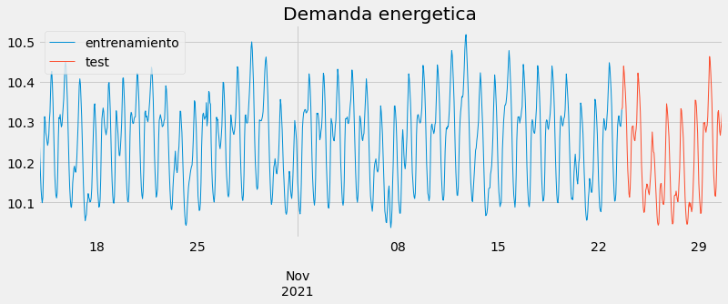

```python
fig, ax = plt.subplots(figsize=(12, 4))
log_train_y.Demand.plot(ax=ax, label='entrenamiento', linewidth=1)
log_test_y.Demand.plot(ax=ax, label='test', linewidth=1)
ax.set_title('Demanda energetica')
ax.legend();
```

# Modelo ETS

Error, Trend and Seasonal

- Es un método de aproximacion para la prevision de series temporales univariantes como es nuestro caso, aquí nos centramos en los componentes de la tendencia y la estacionalidad. Este metodo posee una gran flexibilidad debido a los diferentes rasgos de sus componentes como son la:

|  |  | Estacionalidad |  |
| --- | --- | --- | --- |
| **Tendencia** | N(None) | A (Additive) | M (Multiplicative) |
| N (None) | NN | NA | NM |
| A (Additive) | AN | AA | AM |
| M (Multiplicative) | MN | MA | MM |

Todos los modelos ETS son no estacionarios por lo que en este apartado no aplicaremos los logaritmos y así, no transformamos la serie a estacionaria

Existen 15 modelos con errores aditivos y 15 modelos con errores multiplicativos, simplificando un poco la tabla anterior obtenemos menos modelos. Existen diferentes criterios que tendremos encuenta para nuestro análisis:

- Criterio de información Akaike (AIC) por defecto
- ritero de informacion bayesiano (BIC)

```python
fh_ETS = np.arange(len(test_y))
ETS_auto_model = AutoETS(auto=True, sp=24, n_jobs=-1, information_criterion='aic')
```

```python
train_y = train_y.astype('float64')
```

```python
ETS_auto_model.fit(train_y)
```

```
AutoETS(auto=True, n_jobs=-1, sp=24)
```

```python
ETS_pred = ETS_auto_model.predict(fh_ETS)
print(ETS_pred)
```

```
                        Demand
2021-11-23 15:00  31764.083030
2021-11-23 16:00  32994.005264
2021-11-23 17:00  34410.720504
2021-11-23 18:00  35430.323255
2021-11-23 19:00  36027.983321
...                        ...
2021-11-30 11:00  31783.898705
2021-11-30 12:00  31640.651354
2021-11-30 13:00  31802.728051
2021-11-30 14:00  32228.729348
2021-11-30 15:00  33034.031142

[169 rows x 1 columns]
```

```
(<Figure size 1152x288 with 1 Axes>, <AxesSubplot:>)
```

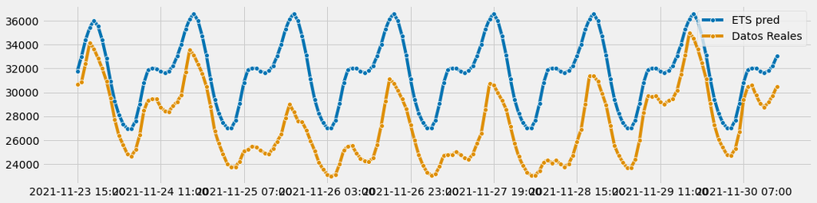

```python
plot_series(ETS_pred,test_y, labels=[ "ETS pred", "Datos Reales"])
```

```
(<Figure size 1152x288 with 1 Axes>, <AxesSubplot:>)
```

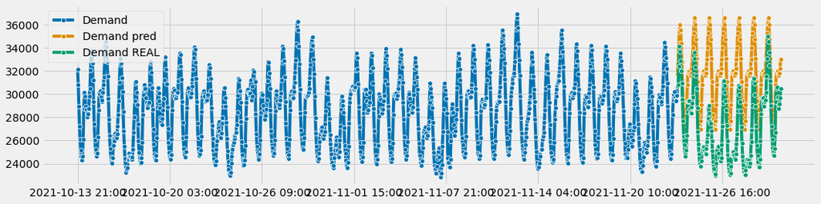

```python
plot_series(train_y, ETS_pred,test_y, labels=["Demand", "Demand pred", "Demand REAL"])
```

```python
print(ETS_auto_model.summary())
```

```
                                 ETS Results
==============================================================================
Dep. Variable:                      y   No. Observations:                  978
Model:                      ETS(MAdM)   Log Likelihood               -7400.720
Date:                Fri, 21 Jan 2022   AIC                          14863.440
Time:                        13:16:49   BIC                          15014.891
Sample:                    10-13-2021   HQIC                         14921.064
                         - 11-23-2021   Scale                            0.000
Covariance Type:               approx
=======================================================================================
                          coef    std err          z      P>|z|      [0.025      0.975]
---------------------------------------------------------------------------------------
smoothing_level         0.9999      0.061     16.454      0.000       0.881       1.119
smoothing_trend         0.8480      0.126      6.704      0.000       0.600       1.096
smoothing_seasonal   6.475e-05        nan        nan        nan         nan         nan
damping_trend           0.8000      0.050     16.118      0.000       0.703       0.897
initial_level        2.875e+04   1177.329     24.418      0.000    2.64e+04    3.11e+04
initial_trend           8.0087   1246.060      0.006      0.995   -2434.224    2450.241
initial_seasonal.0      1.0361      0.031     33.607      0.000       0.976       1.096
initial_seasonal.1      1.0539      0.032     33.148      0.000       0.992       1.116
initial_seasonal.2      1.0406      0.032     32.668      0.000       0.978       1.103
initial_seasonal.3      1.0157      0.032     32.064      0.000       0.954       1.078
initial_seasonal.4      0.9801      0.031     31.618      0.000       0.919       1.041
initial_seasonal.5      0.9511      0.031     30.990      0.000       0.891       1.011
initial_seasonal.6      0.9279      0.030     30.497      0.000       0.868       0.988
initial_seasonal.7      0.9157      0.030     30.119      0.000       0.856       0.975
initial_seasonal.8      0.9110      0.031     29.823      0.000       0.851       0.971
initial_seasonal.9      0.9151      0.031     29.568      0.000       0.854       0.976
initial_seasonal.10     0.9214      0.031     29.407      0.000       0.860       0.983
initial_seasonal.11     0.9228      0.031     29.352      0.000       0.861       0.984
initial_seasonal.12     0.9186      0.031     29.358      0.000       0.857       0.980
initial_seasonal.13     0.8875      0.030     29.452      0.000       0.828       0.947
initial_seasonal.14     0.8373      0.028     29.639      0.000       0.782       0.893
initial_seasonal.15     0.7966      0.027     30.050      0.000       0.745       0.849
initial_seasonal.16     0.7773      0.026     30.328      0.000       0.727       0.828
initial_seasonal.17     0.7782      0.025     30.738      0.000       0.729       0.828
initial_seasonal.18     0.7908      0.025     31.258      0.000       0.741       0.840
initial_seasonal.19     0.8134      0.026     31.811      0.000       0.763       0.864
initial_seasonal.20     0.8469      0.026     32.422      0.000       0.796       0.898
initial_seasonal.21     0.8959      0.027     33.008      0.000       0.843       0.949
initial_seasonal.22     0.9532      0.029     33.413      0.000       0.897       1.009
initial_seasonal.23     1.0000      0.030     33.679      0.000       0.942       1.058
===================================================================================
Ljung-Box (Q):                      743.55   Jarque-Bera (JB):               790.13
Prob(Q):                              0.00   Prob(JB):                         0.00
Heteroskedasticity (H):               1.01   Skew:                            -0.12
Prob(H) (two-sided):                  0.94   Kurtosis:                         7.40
===================================================================================

Warnings:
[1] Covariance matrix calculated using numerical (complex-step) differentiation.
```

### Modelo ARIMA

Este metodo es similar a una regresion estadistica pero aplicando los conceptos de las series de tiempo; por tanto, los pronosticos del modelo vienen explicados por los datos del pasado obviamente ya que no poseemos ninguna variable exógena que nos ayude a la hora de predecir, además de que somos conscientes de la estacionaridad y estacionalidad de nuestra serie a lo largo del tiempo.

El horizonte de prediccion del modelo es principalmente a corto plazo, teniendo en cuenta esto estudiaremos las predicciones que nos arroje el algoritmo.

Calculamos las correlaciones

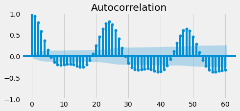

```python
# Autocorrelation

fig, ax = plt.subplots(figsize=(7, 3))
plot_acf(log_hour.Demand, ax=ax, lags=60)
plt.show()
```

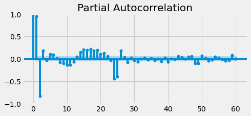

```python
# Partial Autocorrelation
fig, ax = plt.subplots(figsize=(7, 3))
plot_pacf(log_hour.Demand, ax=ax, lags=60)
plt.show()
```

```
(<Figure size 864x576 with 3 Axes>,
 array([<AxesSubplot:>, <AxesSubplot:title={'center':'Autocorrelation'}>,
        <AxesSubplot:title={'center':'Partial Autocorrelation'}>],
       dtype=object))
```

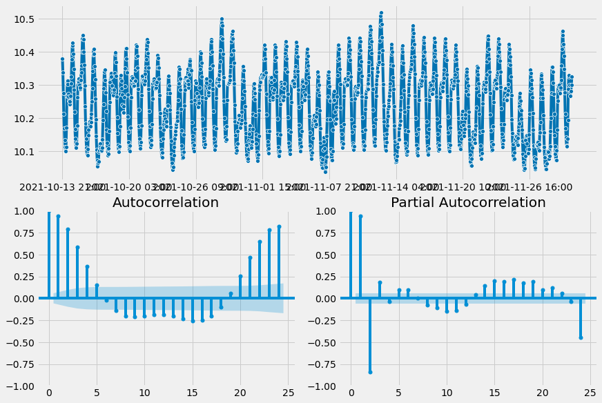

```python
plot_correlations(log_hour)
```

```python
# Forecast Horizon
fh_ARIMA = np.arange(len(test_y))
```

```python
forecaster_ARIMA = AutoARIMA(sp=24 ,suppress_warnings=True, n_jobs=-1)
forecaster_ARIMA.fit(log_train_y)
```

```
AutoARIMA(n_jobs=-1, sp=24, suppress_warnings=True)
```

```python
print(forecaster_ARIMA.summary())
```

```
                                      SARIMAX Results
============================================================================================
Dep. Variable:                                    y   No. Observations:                  978
Model:             SARIMAX(1, 0, 2)x(2, 0, [1], 24)   Log Likelihood                2797.935
Date:                              Fri, 21 Jan 2022   AIC                          -5579.870
Time:                                      13:22:00   BIC                          -5540.786
Sample:                                           0   HQIC                         -5565.000
                                              - 978
Covariance Type:                                opg
==============================================================================
                 coef    std err          z      P>|z|      [0.025      0.975]
------------------------------------------------------------------------------
intercept      0.1358      0.039      3.517      0.000       0.060       0.211
ar.L1          0.9454      0.011     82.690      0.000       0.923       0.968
ma.L1          0.5192      0.025     21.123      0.000       0.471       0.567
ma.L2          0.2602      0.031      8.395      0.000       0.199       0.321
ar.S.L24       0.2297      0.153      1.503      0.133      -0.070       0.529
ar.S.L48       0.5281      0.120      4.407      0.000       0.293       0.763
ma.S.L24       0.4855      0.158      3.068      0.002       0.175       0.796
sigma2         0.0002   5.73e-06     32.446      0.000       0.000       0.000
===================================================================================
Ljung-Box (L1) (Q):                   0.62   Jarque-Bera (JB):               630.85
Prob(Q):                              0.43   Prob(JB):                         0.00
Heteroskedasticity (H):               0.59   Skew:                             0.05
Prob(H) (two-sided):                  0.00   Kurtosis:                         6.93
===================================================================================

Warnings:
[1] Covariance matrix calculated using the outer product of gradients (complex-step).
```

```python
#  Auto ARIMA Forecast
log_y_pred = forecaster_ARIMA.predict(fh_ARIMA)
log_y_pred
```

|  | Demand |
| --- | --- |
| 2021-11-23 15:00 | 10.372406 |
| 2021-11-23 16:00 | 10.372406 |
| 2021-11-23 17:00 | 10.402341 |
| 2021-11-23 18:00 | 10.440688 |
| 2021-11-23 19:00 | 10.430099 |
| ... | ... |
| 2021-11-30 11:00 | 10.284307 |
| 2021-11-30 12:00 | 10.281435 |
| 2021-11-30 13:00 | 10.280588 |
| 2021-11-30 14:00 | 10.285334 |
| 2021-11-30 15:00 | 10.293572 |

169 rows × 1 columns

```python
#  Auto ARIMA Forecast
# Original Time series (Invert log transformation)
np.exp(log_y_pred)
```

|  | Demand |
| --- | --- |
| 2021-11-23 15:00 | 31965.285184 |
| 2021-11-23 16:00 | 31965.285184 |
| 2021-11-23 17:00 | 32936.633096 |
| 2021-11-23 18:00 | 34224.182465 |
| 2021-11-23 19:00 | 33863.708405 |
| ... | ... |
| 2021-11-30 11:00 | 29269.679073 |
| 2021-11-30 12:00 | 29185.732368 |
| 2021-11-30 13:00 | 29161.020230 |
| 2021-11-30 14:00 | 29299.745830 |
| 2021-11-30 15:00 | 29542.096950 |

169 rows × 1 columns

```
(<Figure size 1152x288 with 1 Axes>, <AxesSubplot:>)
```

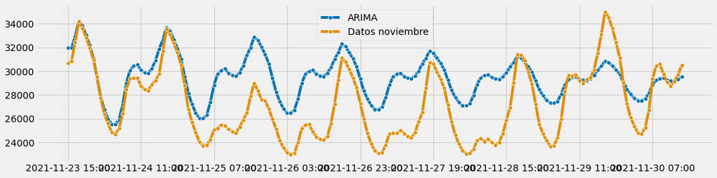

```python
plot_series( np.exp(log_y_pred), test_y, labels=[ "ARIMA", "Datos noviembre"])
```

### Calculamos los errores de la prediccion del test

```python
def mape ( actual , pred ):
    actual, pred = np.array (actual), np.array (pred)
    return np.mean (np.abs ((actual - pred) / actual)) * 100

def mse (actual, pred):
    actual, pred = np.array (actual), np.array (pred)
    return np.square (np.subtract (actual, pred)). mean ()
```

Errores modelo ETS

```python
mape_ETS = mean_absolute_percentage_error(test_y, ETS_pred)
mse_ETS = mse (test_y, ETS_pred)
rmse_ETS= rmse(test_y, ETS_pred)
```

Errores modelo ARIMA

```python
mape_ARIMA = mean_absolute_percentage_error(log_test_y, log_y_pred)
mse_ARIMA = mse (log_test_y, log_y_pred )
rmse_ARIMA = rmse(log_test_y, log_y_pred )
```

Creamos una tabla para estudiar los errores arrojados por el algoritmo

```python
dict_medidas = {'mape': [mape_ARIMA, mape_ETS], "mse" :[mse_ARIMA, mse_ETS],
        'rmse': [rmse_ARIMA, rmse_ETS]
       }

errores = pd.DataFrame(dict_medidas, columns=["mape", "mse", 'rmse'], index = ["ARIMA", "ETS"])
print("-----------------------------------------------------------")
print(f'Estos son los errores obtenidos por el modelo ARiMA y ETS: ')
print("-----------------------------------------------------------")
print(errores)
```

```
-----------------------------------------------------------
Estos son los errores obtenidos por el modelo ARiMA y ETS:
-----------------------------------------------------------
           mape           mse         rmse
ARIMA  0.008869  1.243069e-02     0.111493
ETS    0.148942  2.300892e+07  4796.761332
```

En definitiva, para la parte horaria, seleccionamos el modelo ARIMA frente al ETS (en diferencia a nuestro modelo diario)

# Modelo Final: ARIMA

```python
# Forecast Horizon
fh = np.arange(len(test_y)) + 1 # forecasting horizon
fh
```

```
array([  1,   2,   3,   4,   5,   6,   7,   8,   9,  10,  11,  12,  13,
        14,  15,  16,  17,  18,  19,  20,  21,  22,  23,  24,  25,  26,
        27,  28,  29,  30,  31,  32,  33,  34,  35,  36,  37,  38,  39,
        40,  41,  42,  43,  44,  45,  46,  47,  48,  49,  50,  51,  52,
        53,  54,  55,  56,  57,  58,  59,  60,  61,  62,  63,  64,  65,
        66,  67,  68,  69,  70,  71,  72,  73,  74,  75,  76,  77,  78,
        79,  80,  81,  82,  83,  84,  85,  86,  87,  88,  89,  90,  91,
        92,  93,  94,  95,  96,  97,  98,  99, 100, 101, 102, 103, 104,
       105, 106, 107, 108, 109, 110, 111, 112, 113, 114, 115, 116, 117,
       118, 119, 120, 121, 122, 123, 124, 125, 126, 127, 128, 129, 130,
       131, 132, 133, 134, 135, 136, 137, 138, 139, 140, 141, 142, 143,
       144, 145, 146, 147, 148, 149, 150, 151, 152, 153, 154, 155, 156,
       157, 158, 159, 160, 161, 162, 163, 164, 165, 166, 167, 168, 169])
```

```python
prediccion_final = np.arange(len(test_y)) + 177
```

```python
forecaster_ARIMA = AutoARIMA(sp=24 ,suppress_warnings=True, n_jobs=-1)
forecaster_ARIMA.fit(log_train_y)
```

```
AutoARIMA(n_jobs=-1, sp=24, suppress_warnings=True)
```

```python
#  Auto ARIMA Forecast
log_y_pred = forecaster_ARIMA.predict(prediccion_final)
```

```python
prediccion_horaria_nolog = np.exp(log_y_pred)
prediccion_horaria_nolog
```

|  | Demand |
| --- | --- |
| 2021-12-01 00:00 | 28533.129825 |
| 2021-12-01 01:00 | 28165.439441 |
| 2021-12-01 02:00 | 27889.683956 |
| 2021-12-01 03:00 | 27706.530324 |
| 2021-12-01 04:00 | 27708.519481 |
| ... | ... |
| 2021-12-07 20:00 | 29194.397283 |
| 2021-12-07 21:00 | 29115.862241 |
| 2021-12-07 22:00 | 29007.885561 |
| 2021-12-07 23:00 | 28839.723045 |
| 2021-12-08 00:00 | 28671.190646 |

169 rows × 1 columns

```python
df = pd.DataFrame(prediccion_horaria_nolog)
df.to_csv('pred_ARIMA_horaria.csv')
```

```
(<Figure size 1152x288 with 1 Axes>, <AxesSubplot:>)
```

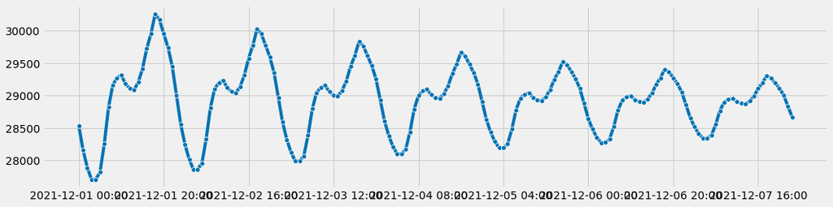

```python
plot_series(prediccion_horaria_nolog)
```